# Investigating US Flights Delays and Cancellations.

## by Ahmed Hashish

## Investigation Overview

In this investigation, I looked at the causes that are mostly affect the total time of delayed flights in our dataset. Additionally, I answered the following interesting questions:

1. What are the top 5 airports that are home to more delays or cancellations?
2. Which year has the worst flights delays?
3. Which year has the highest rate of cancelled flights?
4. What are the most/least efficient airlines? and what are the top 5 efficient airlines?
5. which cause variable is mostly affected the total delay time?
6. For permanent airlines only, which one has the best improvements year by year?
7. What are the preferred times for flights to occur?

## Dataset Overview

The used dataset reports flights in the United States, including carriers, arrival cancellations, arrival delays, and reasons for delays, from 2003 to 2020. The dataset contains 292,669 records, each record contains monthly statistics for each airline with a certain destination airport. 462 records were removed because these records refer airlines that haven't any flight arrived to some airports during some months. 226 null values of monthly delayed time that refers to zero count of delayed flights were replaced with 0 values.

## Distribution of The Total Monthly Delay Time

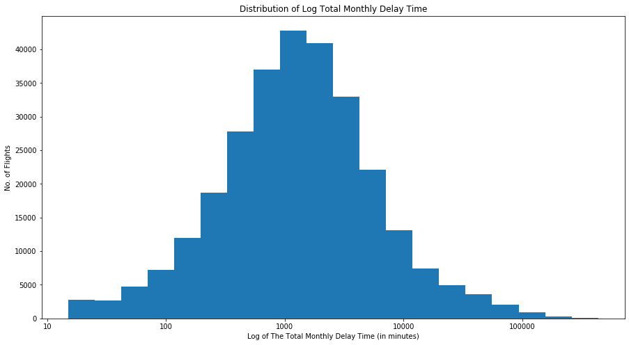

```python
# define our subset of data
df_delayed=df[df['all_del_ct']>0][['all_del_tm']]
# the distribution is highly right skewed, we should use log scale
ticks=np.arange(1,6,1)
plt.figure(figsize=[15,8])
plt.hist(np.log10(df_delayed['all_del_tm']),bins=20);
plt.xlabel('Log of The Total Monthly Delay Time (in minutes)')
plt.ylabel('No. of Flights')
plt.xticks(ticks,10**ticks)
plt.title('Distribution of Log Total Monthly Delay Time');
```

## Distribution of The Monthly Delay Time Caused by Carrier

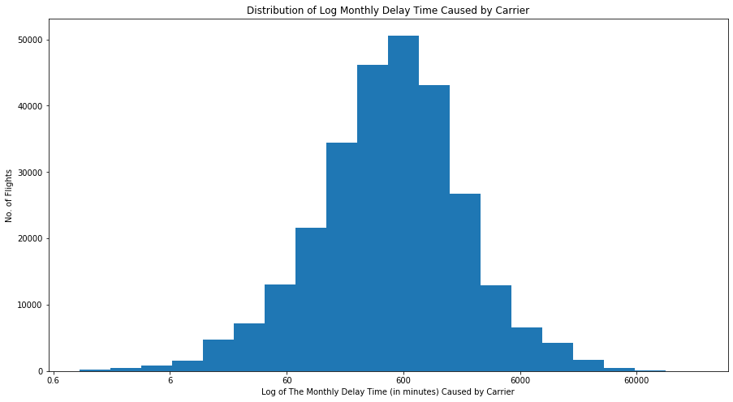

```python
# define our subset of data
df_delayed_car=df[df['carrier_del_tm']>0][['carrier_del_tm','all_del_tm']]
# the distribution is highly right skewed, we should use log scale
plt.figure(figsize=[15,8])
labels=[0.6,6,60,600,6000,60000]
plt.hist(np.log10(df_delayed_car['carrier_del_tm']),bins=20);
plt.xlabel('Log of The Monthly Delay Time (in minutes) Caused by Carrier')
plt.ylabel('No. of Flights')
plt.xticks(np.log10(labels),labels)
plt.title('Distribution of Log Monthly Delay Time Caused by Carrier');
```

## Total Monthly Delay Time vs. Delay Time Caused by Carrier

Plotting both `total monthly delay time` and `delay time caused by carrier` on a logarithmic scale produces an approximately linear relationship.

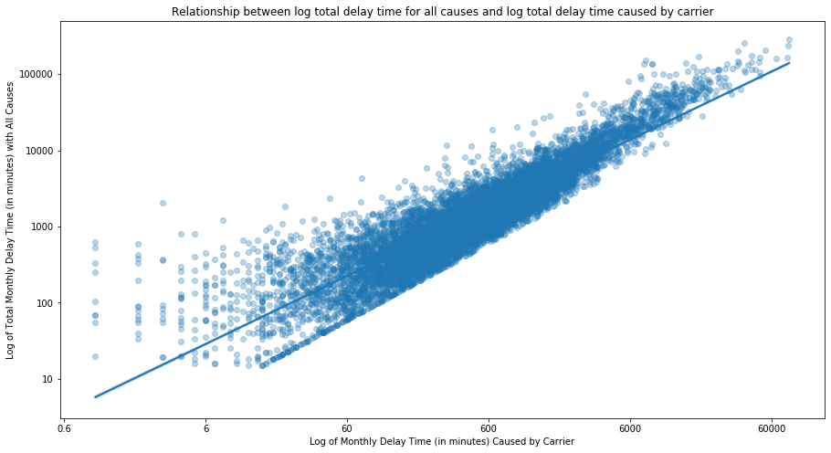

```python
# scatter plot with trend line for the total delay time for all causes and the total delay time caused by carrier
plt.figure(figsize=[15,8])
df_del_car_sample=df_delayed_car.sample(10000)
sb.regplot(np.log10(df_del_car_sample.carrier_del_tm), np.log10(df_del_car_sample.all_del_tm), scatter_kws={'alpha':0.3})
plt.ylabel('Log of Total Monthly Delay Time (in minutes) with All Causes')
plt.xlabel('Log of Monthly Delay Time (in minutes) Caused by Carrier')
plt.title('Relationship between log total delay time for all causes and log total delay time caused by carrier')
yticks=np.arange(1,6,1)
plt.yticks(yticks,10**yticks)
xlabels=[0.6,6,60,600,6000,60000]
plt.xticks(np.log10(xlabels),xlabels);
```

## What are the top 5 airports that are home to more delays or cancellations?

The dataset indicates to the following:

| Top 5 delayed airports | Top 5 cancelled airports |
| --- | --- |
| Atlanta, GA: Hartsfield-Jackson Atlanta International | Chicago, IL: Chicago O'Hare International |
| Chicago, IL: Chicago O'Hare International | Dallas/Fort Worth, TX: Dallas/Fort Worth International |
| Dallas/Fort Worth, TX: Dallas/Fort Worth International | Atlanta, GA: Hartsfield-Jackson Atlanta International |
| Los Angeles, CA: Los Angeles International | New York, NY: LaGuardia |
| Denver, CO: Denver International | Newark, NJ: Newark Liberty International |

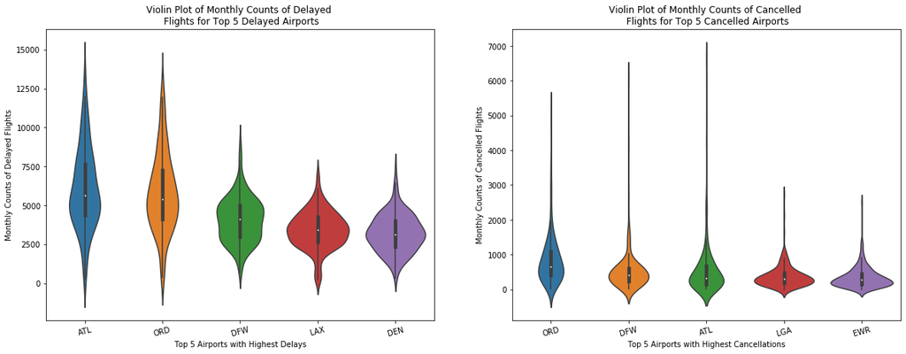

```python
# sum of numbers of delayed and cancelled flights grouped by airport code
des_df=df.groupby(['airport_code'])[['all_del_ct', 'cancelled_ct']].sum()
# find the top 5 airports with highest counts of delayed flights
top_delay_airports=des_df[['all_del_ct']].sort_values(by=['all_del_ct'], ascending=False)[:5]
# find the top 5 airports with highest counts of cancelled flights
top_cancel_airports=des_df[['cancelled_ct']].sort_values(by=['cancelled_ct'], ascending=False)[:5]
# let's find the monthly counts of delayed flights for top 5 delayed airports
df1=df[df.airport_code.isin(top_delay_airports.index)].groupby(['year','month','airport_code'])\
                                                    .sum()[['all_del_ct']].reset_index()
# let's find the monthly counts of cancelled flights for top 5 cancelled airports
df2=df[df.airport_code.isin(top_cancel_airports.index)].groupby(['year','month','airport_code'])\
                                                    .sum()[['cancelled_ct']].reset_index()
# violin plot of monthly counts of delayed flights for top 5 delayed airports
plt.figure(figsize=[20,7])
plt.subplot(1,2,1)
sb.violinplot(data=df1,x='airport_code', y='all_del_ct',order=top_delay_airports.index)
plt.xticks(rotation=15)
plt.xlabel('Top 5 Airports with Highest Delays')
plt.ylabel('Monthly Counts of Delayed Flights')
plt.title('Violin Plot of Monthly Counts of Delayed \n Flights for Top 5 Delayed Airports');
# violin plot of monthly counts of cancelled flights for top 5 cancelled airports
plt.subplot(1,2,2)
sb.violinplot(data=df2,x='airport_code', y='cancelled_ct', order=top_cancel_airports.index)
plt.xticks(rotation=15)
plt.xlabel('Top 5 Airports with Highest Cancellations')
plt.ylabel('Monthly Counts of Cancelled Flights')
plt.title('Violin Plot of Monthly Counts of Cancelled \n Flights for Top 5 Cancelled Airports');
```

### Which year has the worst flights delays?

The year of 2007 is marked to be the highest number and rate of delayed flights. So we could call 2007 the worst year of flights delays.

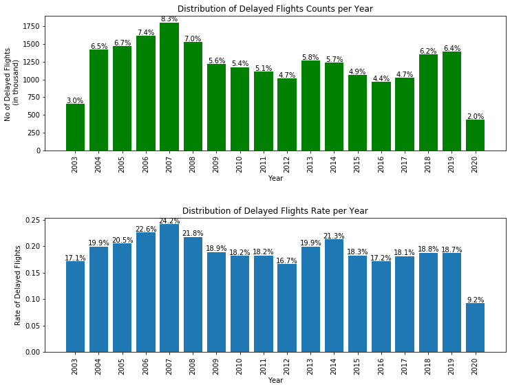

```python
plt.figure(figsize = [12, 9])
plt.subplot(2,1,1)

# distribution of no of delayed flights per year
year_ct=df.groupby(['year'])['all_del_ct'].sum()
ticks=year_ct.index
plt.bar(ticks,year_ct,color='green')
plt.title('Distribution of Delayed Flights Counts per Year')
for i in ticks:
    p = year_ct[i]
    pct_string = '{:0.1f}%'.format(100*p/sum(year_ct))
    plt.text(i, p+10**4, pct_string, ha='center')

plt.xticks(ticks,rotation=90)

plt.xlabel('Year')
plt.ylabel('No of Delayed Flights \n (in thousand)');
ylabels=np.arange(0,2000,250)
plt.yticks(1000*ylabels,ylabels)

plt.subplot(2,1,2)

# distribution of the rate of delayed flights per year
year_ct=df.groupby(['year'])['flights_ct'].sum()
year_delay_ct=df.groupby(['year'])['all_del_ct'].sum()
year_rate=year_delay_ct/year_ct
plt.bar(ticks,year_rate)
plt.title('Distribution of Delayed Flights Rate per Year')
for i in ticks:
    p = year_rate[i]
    pct_string = '{:0.1f}%'.format(100*p)
    plt.text(i, p+0.002, pct_string, ha='center')


plt.xticks(ticks,rotation=90)
plt.xlabel('Year')
plt.ylabel('Rate of Delayed Flights');
plt.subplots_adjust(hspace=0.5)
```

## Which year has the highest rate of cancelled flights?

Dataset shows that the year of 2020 has the highest numbers and rate of cancelled flights. So we could call 2020 the worst year of cancelled flights which is not surprised for anyone because it is the year of COVID-19.

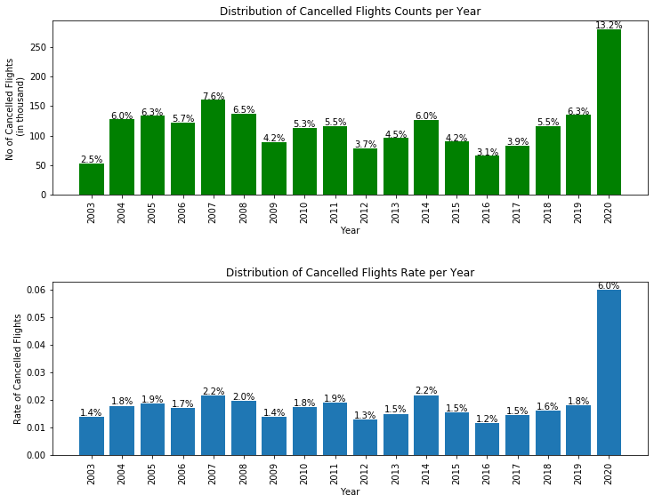

```python
plt.figure(figsize = [12, 9])

plt.subplot(2,1,1)
# distribution of no of cancelled flights per year
year_ct=df.groupby(['year'])['cancelled_ct'].sum()
ticks=year_ct.index
plt.bar(ticks,year_ct,color='green')
plt.title('Distribution of Cancelled Flights Counts per Year')
for i in ticks:
    p = year_ct[i]
    pct_string = '{:0.1f}%'.format(100*p/sum(year_ct))
    plt.text(i, p+10**3, pct_string, ha='center')

plt.xticks(ticks,rotation=90)
plt.xlabel('Year')
plt.ylabel('No of Cancelled Flights \n (in thousand)');
ylabels=np.arange(0,300,50)
plt.yticks(1000*ylabels,ylabels)

plt.subplot(2,1,2)
# distribution of the rate of cancelled flights per year
year_ct=df.groupby(['year'])['flights_ct'].sum()
year_cancel_ct=df.groupby(['year'])['cancelled_ct'].sum()
year_rate=year_cancel_ct/year_ct
plt.bar(ticks,year_rate)
plt.title('Distribution of Cancelled Flights Rate per Year')
for i in ticks:
    p = year_rate[i]
    pct_string = '{:0.1f}%'.format(100*p)
    plt.text(i, p+0.0004, pct_string, ha='center')


plt.xticks(ticks,rotation=90)
plt.xlabel('Year')
plt.ylabel('Rate of Cancelled Flights');
plt.subplots_adjust(hspace=0.5)
```

## What are the most/least efficient airlines? and what are the top 5 efficient airlines?

Dataset shows that "Comair Inc." is most efficient airline and "Hawaiian Airlines Inc." is the least efficient one.

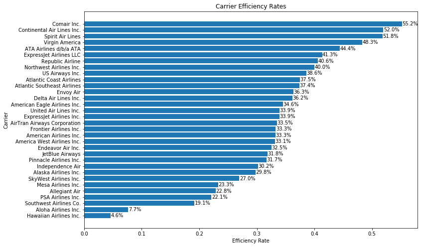

```python
# Calculate efficiency rate for each carrier
sum_tm=df.groupby(['carrier_name'])[['all_del_tm','carrier_del_tm','aircraft_del_tm']].sum()
sum_tm['eff_rate']= 1-(sum_tm.carrier_del_tm+sum_tm.aircraft_del_tm)/sum_tm.all_del_tm
sum_tm=sum_tm.sort_values(by = ['eff_rate'], ascending = True)
# plot horizontal bar chart
labels=sum_tm.index
ticks=np.arange(len(sum_tm.index))
plt.figure(figsize = [12, 8])
plt.barh(ticks,sum_tm['eff_rate'])

for i in ticks:
    p = sum_tm['eff_rate'][i]
    pct_string = '{:0.1f}%'.format(100*p)
    plt.text(p+0.0004,i, pct_string, va='center')


plt.yticks(ticks,labels)
plt.xlabel('Efficiency Rate')
plt.ylabel('Carrier')
plt.title('Carrier Efficiency Rates');
```

## which cause variable is mostly affected the total delay time?

Using correlation plot matrices, we easily can notice that the total time of delayed flights is affected mostly by busy aircraft delay time and by delay time of their airlines.

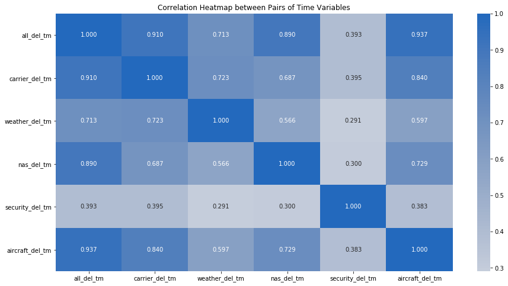

```python
# correlation heatmap between pairs of time variables only
plt.figure(figsize = [15, 8])
sb.heatmap(df[time_cols].corr(), annot = True, fmt = '.3f',
           cmap = 'vlag_r', center = 0)
plt.title('Correlation Heatmap between Pairs of Time Variables')
plt.show()
```

## For permanent airlines only, which one has the best improvements year by year?

Dataset shows that "Alaska Airlines Inc." has the highest increasing trend which means that "Alaska Airlines Inc." has been improving their services over time perfectly more than others carriers.

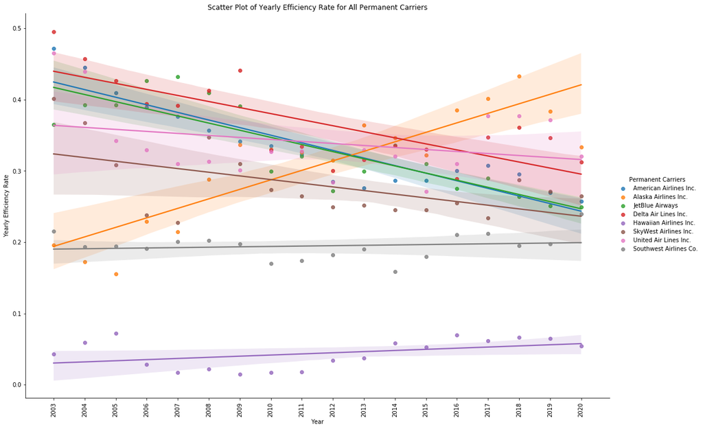

```python
# list of all permanent carriers that starting from 2003 up to 2020
start_car=df[df.year==2003]['carrier_name'].unique()
cont_car=df[df.year==2020]['carrier_name'].unique()
all_time_car=[value for value in cont_car if value in start_car]
# Calculate the yearly efficiency rate for each carrier
sum_tm=df[df.carrier_name.isin(all_time_car)].groupby(['carrier_name','year'])\
                                            [['all_del_tm','carrier_del_tm','aircraft_del_tm']].sum()
sum_tm['eff_rate']= 1-(sum_tm.carrier_del_tm+sum_tm.aircraft_del_tm)/sum_tm.all_del_tm
sum_tm.reset_index(inplace=True)
# Plot scatter chart with trend
g=sb.FacetGrid(data=sum_tm, hue='carrier_name', hue_order=all_time_car, height=10, aspect=1.5)
g=g.map(sb.regplot, 'year', 'eff_rate')
g.add_legend(title='Permanent Carriers')
plt.xticks(np.arange(2003,2021),rotation=90)
plt.xlabel('Year')
plt.ylabel('Yearly Efficiency Rate')
plt.title('Scatter Plot of Yearly Efficiency Rate for All Permanent Carriers');
```

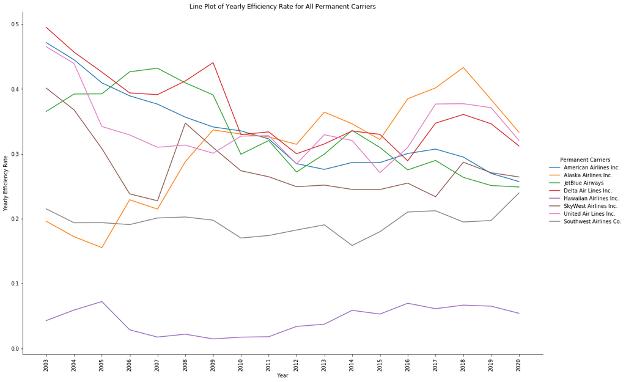

```python
# Plot line chart
g=sb.FacetGrid(data=sum_tm, hue='carrier_name', hue_order=all_time_car, height=10, aspect=1.5)
g=g.map(sb.lineplot, 'year', 'eff_rate')
g.add_legend(title='Permanent Carriers')
plt.xticks(np.arange(2003,2021),rotation=90)
plt.xlabel('Year')
plt.ylabel('Yearly Efficiency Rate')
plt.title('Line Plot of Yearly Efficiency Rate for All Permanent Carriers');
```

## What are the preferred times for flights to occur?

Dataset shows that September is the perfect month has fewest delays, although November has the least flight cancellation rate.

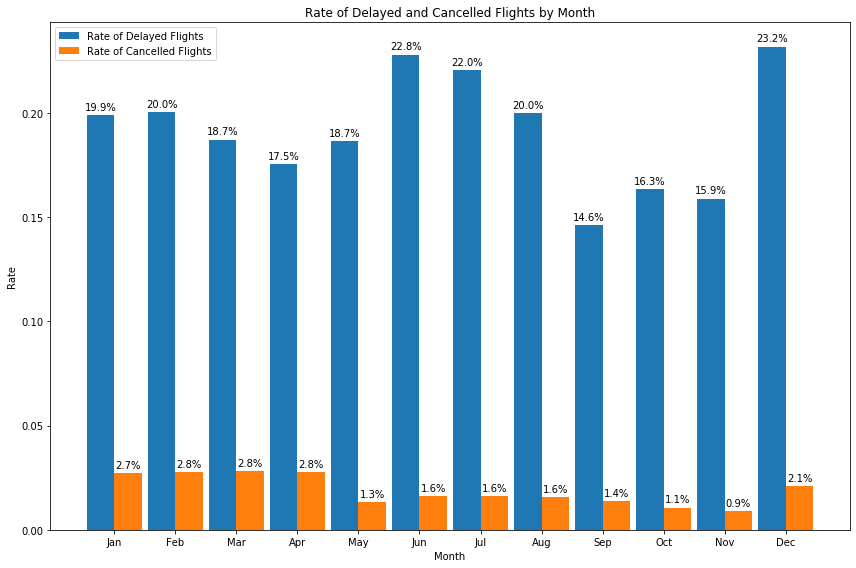

```python
# Calculate monthly rate of delayed and cancelled flights
month_ct=df.groupby(['month'])['flights_ct'].sum()
month_delay_ct=df.groupby(['month'])[['all_del_ct','cancelled_ct']].sum()
month_rate=month_delay_ct.div(month_ct, axis=0).reset_index()

x = np.arange(12)  # the label locations
width = 0.45  # the width of the bars

fig, ax = plt.subplots(figsize=(12, 8))
rects1 = ax.bar(x - width/2, month_rate.all_del_ct, width, label='Rate of Delayed Flights')
rects2 = ax.bar(x + width/2, month_rate.cancelled_ct, width, label='Rate of Cancelled Flights')

# Add some text for labels, title and custom x-axis tick labels, etc.

ax.set_ylabel('Rate')
ax.set_xlabel('Month')
ax.set_title('Rate of Delayed and Cancelled Flights by Month')
ax.set_xticks(x)
Labels=['Jan','Feb','Mar','Apr','May','Jun','Jul','Aug','Sep','Oct','Nov','Dec']
ax.set_xticklabels(Labels) # you can put
ax.legend()


def autolabel(rects):
    """Attach a text label above each bar in *rects*, displaying its height."""
    for rect in rects:
        height = rect.get_height()
        ax.annotate('{:0.1f}%'.format(100*height),
                    xy=(rect.get_x() + rect.get_width() / 2, height),
                    xytext=(0, 3),  # 3 points vertical offset
                    textcoords="offset points",
                    ha='center', va='bottom')


autolabel(rects1)
autolabel(rects2)

fig.tight_layout()

plt.show()
```